# Analyses avec le code OPR

Auteur : Domitille Jarrige

Date : 2021-04-15

## Script python

J'ai réalisé ce script qui reçoit en entrée un ou plusieurs fichiers **fasta** et qui va en extraire les séquences de protéines. Les motifs OPR éventuels sont détectés avec l'utilisation d'une expression régulière pour le moment.

Le programme est ensuite capable de rechercher les occurences de ce motif putatif dans un génome (**gb**, **embl**) éventuellement donné en dernière entrée par l'utilisateur.

Ce notebook a pour objectif de faire une démonstration de ses capacités actuelles.

**Installation de Biopython pour extraire les séquences des fasta**

**De pandas, numpy et matplotlib pour le traitement et la visualisation des données générées**

```python
# !pip install Biopython
# !pip install matplotlib
# !pip install pandas
# !pip install numpy
```

On fait tourner le script en lui donnant en arguments un ou plusieurs fichiers fasta protéique. On donne en dernier argument soit "NoGenome" si on ne veut pas chercher de cibles dans un génome, ou le chemin vers le génome souhaité (en format genbank or embl).

Le programme demande ensuite si l'on veut produire des fichiers de prédiction indépendants et détaillés pour chaque protéine. Il serait préferable de ne pas le faire si on a beaucoup de protéines dans le(s) fichier(s) !

```python
import pandas as pd
import numpy as np
import matplotlib.pyplot as plt
```

#### Architecture du projet

```python
!tree
```

```
.
├── data
│   ├── Cre.chloroplast_genome.gb
│   └── OPR.Cre.fasta.txt
├── etudes_code_OPR.ipynb
├── images
├── log
├── OPR_code_prediction.py
└── results

4 directories, 4 files
```

```python
%run OPR_code_prediction.py data/OPR.Cre.fasta.txt data/Cre.chloroplast_genome.gb
```

```
Making predictions...
Detected genome format: genbank
Predictions complete!
```

#### Sorties du programme :

- un fichier tableau qui résume la cible prédite en format IUPAC pour chaque OPR (csv)
- *optionnel : un fichier csv pour chaque OPR qui contient la matrice de probabilité pour chaque nucléotide de la cible prédite*
- *optionnel : un fichier csv présentant toutes les cibles potentielles détectées dans le génome de référence fourni. (pour l'instant donne les cibles dans les CDS ou les 5'UTR balisés grossièrement : 500 nt en amont du START...)*
- un fichier log qui résume l'activité du programme

**Fichier log :**

```python
# Début du fichier log.out
!head -n 20 log/log.out
```

```
OPR code prediction
*******************
Start time: 2021-4-15 18:32:28

Scanning data/Cre.chloroplast_genome.gb for putative targets of ChlreOPR1...
ChlreOPR1 putative targets found in 1 loci
No target prediction file generated for ChlreOPR1
Scanning data/Cre.chloroplast_genome.gb for putative targets of Chlre_OPR2...
Chlre_OPR2 putative targets found in 4 loci
Target prediction file generated for Chlre_OPR2
Scanning data/Cre.chloroplast_genome.gb for putative targets of Chlre_OPR3...
Chlre_OPR3 putative targets found in 1 loci
No target prediction file generated for Chlre_OPR3
Scanning data/Cre.chloroplast_genome.gb for putative targets of Chlre_OPR4...
Chlre_OPR4 putative targets found in 419 loci
No target prediction file generated for Chlre_OPR4
Scanning data/Cre.chloroplast_genome.gb for putative targets of Chlre_OPR5...
Chlre_OPR5 putative targets found in 11 loci
Target prediction file generated for Chlre_OPR5
Scanning data/Cre.chloroplast_genome.gb for putative targets of Chlre_OPR6...
```

```python
# Fin du fichier log.out
!tail -n 10 log/log.out
```

```
Scanning data/Cre.chloroplast_genome.gb for putative targets of Chlre_OPR120...
Chlre_OPR120 putative targets found in 1 loci
Target prediction file generated for Chlre_OPR120
Scanning data/Cre.chloroplast_genome.gb for putative targets of Chlre_OPR121...
Chlre_OPR121 putative targets found in 1 loci
No target prediction file generated for Chlre_OPR121

End time: 2021-4-15 18:44:47
*******************
Predictions complete !
```

**Tableau individuel avec matrice de prédiction :**

```python
mthi1_df = pd.read_csv("results/Chlre_OPR100.csv", sep=";")
mthi1_df.head(10)
```

|  | OPR motif | A | U | C | G |
| --- | --- | --- | --- | --- | --- |
| 0 | NYDSWDTTLSLWAYAQLDHYDEGALRALCDAAVEVA | 0.01 | 0.29 | 0.00 | 0.70 |
| 1 | IFKPVDCANAVVAFAHLDYVHPELLRQIVQTVLDTL | 0.01 | 0.29 | 0.00 | 0.70 |
| 2 | DYAPGEVCQVLWGFARLGVHPGPAFLAEVVDAVQWR | 0.05 | 0.95 | 0.00 | 0.00 |
| 3 | GYGTQELGMVLWALVRLGYKPGPRFLRDVESVLLAR | 0.05 | 0.95 | 0.00 | 0.00 |
| 4 | HMAPGDIAITVWSFARLRYKAVRFLDEVPAAVGPQL | 0.01 | 0.29 | 0.00 | 0.70 |
| 5 | KCRSSELCSLISGFATAHHYHKSLLDAVADVLLSRL | 0.05 | 0.95 | 0.00 | 0.00 |
| 6 | GLSHHEVATALWTFGTFRHRPAHPDFAKQVAAALYA | 0.05 | 0.95 | 0.00 | 0.00 |
| 7 | SFSPQGLAMVVKALAQLQWRSEPLMEQLIAAAEAKL | 0.50 | 0.40 | 0.08 | 0.02 |
| 8 | AFKPLELSQLLWGLTALQCRDLHIYYAVVRRCIAIL | 0.05 | 0.95 | 0.00 | 0.00 |

```python
mdb1_df = pd.read_csv("results/Chlre_OPR62.csv", sep=";")
mdb1_df.head(20)
```

|  | OPR motif | A | U | C | G |
| --- | --- | --- | --- | --- | --- |
| 0 | GGSTSSTSGAAAAAATATPTTTATASGNPDDHQLRQ | 1 | 0 | 0 | 0 |
| 1 | QPPPSSLQARTALTRAISTCPTYTRLHQLLLDNALD | 1 | 0 | 0 | 0 |
| 2 | VYHSCAALSRVLALHRRGLSPRESRLFKEGCSTLQS | 0.8 | 0.15 | 0.05 | 0 |
| 3 | ELHPRAVVVAAYSLARLELPDRELLAGLAAAVEPQL | 0.8 | 0.15 | 0.05 | 0 |
| 4 | ALQPRGLASLLWAFARQGHQPPPKWMDAFLSCCAAE | 0.5 | 0.4 | 0.08 | 0.02 |
| 5 | RFAPREVSTLLWGLARLHYKVAPARLRQLLEHSQAQ | 0.05 | 0.95 | 0 | 0 |
| 6 | SFCGRSLSNVVYSLALSQQHPGEEWLAAAQARAVAL | 1 | 0 | 0 | 0 |
| 7 | AFSPQGLTQMAWGLAKLGCPPTSALLDMVCAHAAAR | 0.5 | 0.4 | 0.08 | 0.02 |
| 8 | PYNGLDLSTLMYALGSWGAQPRPEVGRRLLLALEWE | 0.01 | 0.29 | 0 | 0.7 |
| 9 | RLEANQLCNCVWACARLRLYPSRSWLRDFYDASYRQ | 0.31 | 0.38 | 0.3 | 0.01 |
| 10 | YFKPVDLSQSLWALARLGAAPPEAWLGGALNRLQHT | 0.01 | 0.29 | 0 | 0.7 |
| 11 | MFSPVEVANTMWALAKMGVRGERLPAEVLALFFIAT | 0.05 | 0.95 | 0 | 0 |
| 12 | SFKPQELCSMVWALAHMRRRPDKEWTAEFLKVTYHK | 0.05 | 0.95 | 0 | 0 |
| 13 | SMSGWCLATLAWSLAELQLSPPPAWTYSFVNAARAL | ? | ? | ? | ? |
| 14 | SALTYPALSVAAGAADAAGSGSGLSAIDLGQIITGL | ? | ? | ? | ? |

```python
mde1_df = pd.read_csv("results/Chlre_OPR113.csv", sep=";")
mde1_df.head(20)
```

|  | OPR motif | A | U | C | G |
| --- | --- | --- | --- | --- | --- |
| 0 | PLATTPTSPAAASTAAASGRRHTPELRPPLPRLWPA | ? | ? | ? | ? |
| 1 | AAAARAATAPLAAVASTSAAASPSAATRPHVPSAVQ | 0.8 | 0.15 | 0.05 | 0 |
| 2 | PVPGVQVQVGAAAVSGGWGVSLAGSATTSTSNGSSR | 0.31 | 0.38 | 0.3 | 0.01 |
| 3 | PARPVQLLGGAALTRAIKSCASPAQLQQLYSTHSGS | 0.31 | 0.38 | 0.3 | 0.01 |
| 4 | TAATANAATATATATAASSSAAAAARQGPSGSSKQQ | ? | ? | ? | ? |
| 5 | LLQPRAASNAMWAVARLGLRLRASWWEAQAGRLMPG | 0.8 | 0.15 | 0.05 | 0 |
| 6 | GPTGRDLSNALYALGLAAAAAEAAAEAEAGGSGAGN | 0 | 0.6 | 0 | 0.4 |
| 7 | PLTPRSLAAMASGLSLLLRLRRPTAGTSGAAAATAS | 1 | 0 | 0 | 0 |
| 8 | TPPPAPAAAAAAAASSSSSSSTVASASKRPPQWRRW | ? | ? | ? | ? |
| 9 | YVPSRQLLAALAAAARRRLCGLSPDRLSQMLWAMAR | 0.31 | 0.38 | 0.3 | 0.01 |
| 10 | APPPATASSGAATAATAVPPPLLPARTAVQLLVALR | ? | ? | ? | ? |
| 11 | RALPNQAVREAAALREVVRQLAALTSAAAWLADPSA | 0.31 | 0.38 | 0.3 | 0.01 |
| 12 | RLMSAAAAAGAAAAGGRSQLLSLSLSLSLSLDEVAT | 0.8 | 0.15 | 0.05 | 0 |
| 13 | AAMATAASGQAAAAAADAATSRRGARRAHASAVAAA | 0.8 | 0.15 | 0.05 | 0 |
| 14 | AAEAAQLVRLAAAVAAVLPELPEGSSSSAEAAEAAE | 0.31 | 0.38 | 0.3 | 0.01 |
| 15 | VCVPLPAALWLAVYRSTFRTMQLRMQQAAVAAERAA | ? | ? | ? | ? |
| 16 | LLPAAQLVGLAYSLARHPPPQPPPQRWMRLLMQVCV | 0.31 | 0.38 | 0.3 | 0.01 |

Comme vous l'avez peut-être remarqué, la détection des OPR est assez rudimentaire et ne prend en compte que la séquence... Si vous avez des idées pour améliorer la détection des motifs OPR, je suis prenneuse !

**Tableau de données avec toutes les OPR :**

La colonne "Unreadable" est définie selon le taux de "?" dans la cible putative :

- strictement moins de 30% de "?" : readable
- strictement moins de 50% de "?" : partially_readable
- 50% et plus de "?" : unreadable

```python
opr_df = pd.read_csv("results/OPR.Cre.fasta.txt.results.csv", sep=";", index_col=0)
opr_df.head(10)
```

| Protein_name | Predicted_target_seq | Target_seq_len | Unreadable |
| --- | --- | --- | --- |
| ChlreOPR1 | HA?H | 4 | readable |
| Chlre_OPR2 | ?WHK?AUHKA | 10 | readable |
| Chlre_OPR3 | W?A | 3 | partially_readable |
| Chlre_OPR4 | AAUAW? | 6 | readable |
| Chlre_OPR5 | AKWWUKW | 7 | readable |
| Chlre_OPR6 | ?AUUUWU?AWAAA | 13 | readable |
| Chlre_OPR7 | A?KUUUHH?H | 10 | readable |
| Chlre_OPR8 | UAH??A?UAWUA | 12 | readable |
| Chlre_OPR9 | A?UAAAHKH? | 10 | readable |
| Chlre_OPR10 | HK?A | 4 | readable |

**Observons quelques statistiques sur la prédiction de cibles :**

```python
# Séparation des données selon la solidité de la prédiction
opr_readable           = opr_df[ (opr_df["Unreadable"] == "readable") ]
opr_unreadable         = opr_df[ (opr_df["Unreadable"] == "unreadable") ]
opr_partially_readable = opr_df[ (opr_df["Unreadable"] == "partially_readable") ]
```

```python
data = {"taille"             : [],
        "readable"           : [],
        "partially_readable" : [],
        "unreadable"         : []}

for i in range(1, 34):
    temp_liste = list(opr_df[ opr_df["Target_seq_len"] == float(i) ]["Unreadable"].values)
    data["taille"].append(i)
    data["readable"].append(temp_liste.count("readable"))
    data["partially_readable"].append(temp_liste.count("partially_readable"))
    data["unreadable"].append(temp_liste.count("unreadable"))

opr_stat_df = pd.DataFrame.from_dict(data)
```

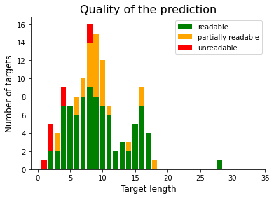

```python
x = list(range(1,34))

greenbars  = list(opr_stat_df["readable"].values)
orangebars = list(opr_stat_df["partially_readable"].values)
redbars    = list(opr_stat_df["unreadable"].values)
bars = []

for k, m in zip(greenbars, orangebars):
    bars.append(k + m)

plt.bar(x,
        greenbars,
        color="green",
        label="readable")

plt.bar(x,
        orangebars,
        bottom=greenbars,
        color="orange",
        label="partially readable")

plt.bar(x,
        redbars,
        bottom=bars,
        color="red",
        label="unreadable")

plt.title("Quality of the prediction", fontsize=16)
plt.xlabel("Target length", size="large")
plt.ylabel("Number of targets", size="large")
plt.legend()
```

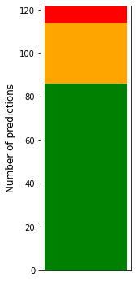

```python
abscisses = [1]
fig = plt.figure()
fig.set_size_inches(2, 6)

plt.bar(abscisses,
        len(opr_readable),
        color="green",
        label="readable")

plt.bar(abscisses,
        len(opr_partially_readable),
        bottom=len(opr_readable),
        color="orange",
        label="partially readable")

plt.bar(abscisses,
        len(opr_unreadable),
        bottom=len(opr_readable) + len(opr_partially_readable),
        color="red",
        label="unreadable")

plt.ylim(0, 122)
plt.ylabel("Number of predictions", size="large")
plt.tick_params(labelbottom=False)
plt.tick_params(bottom=False)
```

Evidemment le critère "Unreadable" est complètement arbitraire et ne reflète pas le problème de la taille des séquences cibles pour la détection par la suite...

**Tableau des cibles putatives d'une OPR :**

On ne cherche que les cibles de 5 nt de longueur ou plus.

J'ai fixé ici un seuil élevé pour la détection des motifs, de sorte à ce que le taux de faux positifs soit 100 000 fois inférieur à celui des faux négatifs... La prédiction est très stringente ! Ce paramètre peut être modifié aisément, des seuils plus faibles augmentent beaucoup le nombre de séquences cibles putatives découvertes.

```python
pred_mthi1_df = pd.read_csv("results/Chlre_OPR100_target_pred.csv", sep=";", index_col=0)
pred_mthi1_df[pred_mthi1_df["Feature"] == ("atpH 5'UTR")]
pred_mthi1_df.head(10)
```

|  | Motif | Position | Score | Feature |
| --- | --- | --- | --- | --- |
| 0 | GGTTGTTAT | 115053 | 14.187093 | rpoC2 |
| 1 | GGTTGTTAT | 118225 | 14.187093 | trnQ 5'UTR |
| 2 | GGTTGTTAT | 128071 | 14.187093 | cemA |
| 3 | GGTTGTTAT | 128907 | 14.187093 | atpH 5'UTR |
| 4 | GGTTGTTAT | 195519 | 14.187093 | rpoC1b |

```python
pred_mdb1_df = pd.read_csv("results/Chlre_OPR62_target_pred.csv", sep=";", index_col=0)
pred_mdb1_df.head(10)
```

|  | Motif | Position | Score | Feature |
| --- | --- | --- | --- | --- |
| 0 | AAAAATATGCTTTAC | 10897 | 15.507924 | chlB |
| 1 | AAAAATATGCTTTAC | 10897 | 15.507924 | trnP 5'UTR |
| 2 | AAAAATACGTGTTTT | 104347 | 14.836348 | rps3 5'UTR |
| 3 | AAAAATAAGCGTTAG | 161939 | 17.999105 | atpB 5'UTR |

```python
pred_mde1_df = pd.read_csv("results/Chlre_OPR113_target_pred.csv", sep=";", index_col=0)
pred_mde1_df.head()
```

|  | Motif | Position | Score | Feature |
| --- | --- | --- | --- | --- |
| 0 | CAACCAGAAACTAACGC | 81705 | 12.020917 | psbB |
| 1 | CAATCATACCACAACGT | 137286 | 11.969627 | chlN |

```python
# une OPR au hasard :
pred_opr44_df = pd.read_csv("results/Chlre_OPR44_target_pred.csv", sep=";", index_col=0)
pred_opr44_df.head(20)
```

|  | Motif | Position | Score | Feature |
| --- | --- | --- | --- | --- |
| 0 | AACTAATAAAA | 3789 | 14.047301 | petA |
| 1 | AACTAATAAAA | 22615 | 14.047301 | rpl36 5'UTR |
| 2 | AAATAATAAAA | 34014 | 13.137121 | rps4 |
| 3 | AAATAATAAAA | 41166 | 13.137121 | trnI 5'UTR |
| 4 | AAATAATAAAA | 41166 | 13.137121 | trnA 5'UTR |
| 5 | AATTAATAAAA | 86356 | 13.137121 | rpoA 5'UTR |
| 6 | AATTAATAAAA | 102136 | 13.137121 | psbF 5'UTR |
| 7 | AAATAATAAAA | 107700 | 13.137121 | rpoC2 5'UTR |
| 8 | AATTAATAAAA | 113470 | 13.137121 | rpoC2 |
| 9 | AAGTAATAAAA | 115992 | 14.047301 | rpoC2 |
| 10 | AAGTAATAAAA | 122260 | 14.047301 | trnG2 5'UTR |
| 11 | AAGTAATAAAA | 126397 | 14.047301 | psbI 5'UTR |
| 12 | AAATAATAAAA | 153025 | 13.137121 | trnA 5'UTR |
| 13 | AAATAATAAAA | 153025 | 13.137121 | trnI 5'UTR |
| 14 | AAATAATAAAA | 180960 | 13.137121 | ORF2971 |
| 15 | AACTAATAAAA | 183215 | 14.047301 | ORF2971 |

**Un aperçu de tous les fichiers produits, lors de l'exécution du programme :**

Attention il y en a beaucoup avec l'option des fichiers indépendants !

```python
!tree
```

```
.
├── data
│   ├── Cre.chloroplast_genome.gb
│   └── OPR.Cre.fasta.txt
├── etudes_code_OPR.ipynb
├── images
├── log
│   └── log.out
├── OPR_code_prediction.py
└── results
    ├── Chlre_OPR100.csv
    ├── Chlre_OPR100_target_pred.csv
    ├── Chlre_OPR101.csv
    ├── Chlre_OPR101_target_pred.csv
    ├── Chlre_OPR102.csv
    ├── Chlre_OPR102_target_pred.csv
    ├── Chlre_OPR103.csv
    ├── Chlre_OPR104.csv
    ├── Chlre_OPR105.csv
    ├── Chlre_OPR105_target_pred.csv
    ├── Chlre_OPR106.csv
    ├── Chlre_OPR106_target_pred.csv
    ├── Chlre_OPR107.csv
    ├── Chlre_OPR107_target_pred.csv
    ├── Chlre_OPR108.csv
    ├── Chlre_OPR108_target_pred.csv
    ├── Chlre_OPR109.csv
    ├── Chlre_OPR10.csv
    ├── Chlre_OPR110.csv
    ├── Chlre_OPR110_target_pred.csv
    ├── Chlre_OPR111.csv
    ├── Chlre_OPR111_target_pred.csv
    ├── Chlre_OPR112.csv
    ├── Chlre_OPR112_target_pred.csv
    ├── Chlre_OPR113.csv
    ├── Chlre_OPR113_target_pred.csv
    ├── Chlre_OPR114.csv
    ├── Chlre_OPR114_target_pred.csv
    ├── Chlre_OPR115.csv
    ├── Chlre_OPR115_target_pred.csv
```

[output cut: 160 more lines]

```
    ├── Chlre_OPR94.csv
    ├── Chlre_OPR94_target_pred.csv
    ├── Chlre_OPR95.csv
    ├── Chlre_OPR95_target_pred.csv
    ├── Chlre_OPR96.csv
    ├── Chlre_OPR97.csv
    ├── Chlre_OPR97_target_pred.csv
    ├── Chlre_OPR98.csv
    ├── Chlre_OPR98_target_pred.csv
    ├── Chlre_OPR99.csv
    ├── Chlre_OPR99_target_pred.csv
    ├── Chlre_OPR9.csv
    └── OPR.Cre.fasta.txt.results.csv

4 directories, 208 files
```

### Les points à améliorer ou ajuster :

- amélioration de la détection des motifs OPR
- éventuellement : proposition d'options avec différents types de motifs OPR ? Par exemple selon la famille de l'organisme étudié par l'utilisateur ? Ou le type M, T ou NCL ?
- ajustement des scores arbitraires donné par le code OPR théorique + expérimental
- seuil d'exigence pour la sélection de séquences cibles putatives à ajuster
- scan dans un jeu d'ARN ? Voire de footprint ?
- d'autres idées ?

Si vous voulez on peut tester le programme avec d'autre données (génome mitochondial, autre organisme...).